# Chapter 6: Model Qualification

MI-210 Essentials of Population PKPD M&S — Pumas Edition

Author

Adapted from Marc R. Gastonguay, Ph.D. (Metrum Institute)

Published

April 18, 2026

# 1 Overview

Model qualification (or evaluation) methods help assess how well a model describes the observed data and whether it is suitable for its intended purpose:

- Assumption Checking
- Test Data Sets
- Log-Likelihood Profile
- Bootstrap
- Leverage Analysis
- Predictive Performance (VPC)
- Posterior Predictive Check

# 2 A Risk-Based Approach to Model Qualification

- The level of qualification should match the intended use of the model
- Exploratory models require less rigorous qualification than models used for regulatory decision-making
- All models should pass basic assumption checks and diagnostic evaluation

# 3 Model Qualification Methods

## 3.1 Assumption Checking

- Distributional assumptions on random effects (ETAs should be approximately normal)
- Residual error assumptions (CWRES should be approximately N(0,1))
- Structural model assumptions (systematic trends in residuals indicate misspecification)

**Interpreting Diagnostic Plots: What Each Panel Reveals**

Standard goodness-of-fit diagnostics each target a specific aspect of model adequacy:

1. **DV vs PRED** — Assesses population-level structural fit. Systematic deviations from the line of identity indicate structural model misspecification (e.g., wrong number of compartments or incorrect absorption model).
2. **DV vs IPRED** — Assesses individual-level fit after incorporating empirical Bayes estimates. Scatter should be tighter than DV vs PRED; if not, the random effects structure may be inadequate.
3. **CWRES vs PRED** — Evaluates residual error model adequacy. A fan-shaped (heteroscedastic) pattern suggests proportional error is needed; a U-shaped trend suggests structural misspecification persists even after accounting for random effects.
4. **CWRES vs TIME** — Detects time-dependent model misspecification, such as missing absorption lag time, autoinduction, or time-varying clearance.

If the model is correctly specified, CWRES should be approximately $N(0,1)$ with no systematic trends. Deviations from this expectation guide targeted model refinement.

## 3.2 Bootstrap: Qualification of Parameter Estimates

**Bootstrap vs. Asymptotic Standard Errors**

Asymptotic standard errors derived from the Fisher information matrix assume that the likelihood surface is approximately **quadratic** (i.e., the parameter estimates are normally distributed) near the minimum. This assumption can fail for small datasets, when variance parameters are estimated near their boundary (e.g., $\omega^2 \approx 0$), or when the likelihood surface is flat or irregular. In such cases, asymptotic confidence intervals may be misleading. **Bootstrap resampling** makes no distributional assumptions: by repeatedly resampling subjects with replacement and re-estimating the model, it constructs empirical confidence intervals that reflect the actual sampling distribution of the estimator. However, bootstrap is not without limitations — if the convergence rate across resamples falls below approximately 80%, this signals model instability or overparameterization, and the bootstrap results themselves become unreliable.

Bootstrap provides non-parametric confidence intervals for parameter estimates by resampling subjects with replacement.

### 3.2.1 Base PK Model

The book uses a 1-compartment IV model with combined error (ADVAN1 TRANS2):

```julia
pk_df = CSV.read(joinpath(data_dir, "prob_5_1.csv"), DataFrame)
rename!(pk_df,
    :ID => :id, :DV => :dv, :AMT => :amt, :TIME => :time,
    :II => :ii, :ADDL => :addl, :RATE => :rate,
)

# Prepare for Pumas
pk_df.evid = ifelse.(pk_df.amt .> 0, 1, 0)
pk_df.cmt = fill(1, nrow(pk_df))
pk_df.dv = ifelse.(pk_df.evid .== 1, missing, pk_df.dv)

pop = read_pumas(pk_df; covariates = [:HT, :WT, :CLCR, :SEX, :AGE])
println("Subjects: ", length(pop))
```

```
Subjects: 40
```

```julia
# 1-cpt IV model with BLOCK(2) OMEGA and combined error
# From 501.ctl: ADVAN1 TRANS2, Y=F + F*ERR(1) + ERR(2)
pk_model = @model begin
    @metadata begin
        desc = "1-Cpt IV PopPK (Bootstrap Base Model)"
    end
    @param begin
        tvCL   ∈ RealDomain(lower = 0.0, init = 13.0)
        tvV    ∈ RealDomain(lower = 0.0, init = 75.0)
        Ω      ∈ PSDDomain(2)
        σ_prop ∈ RealDomain(lower = 0.0, init = 0.2)
        σ_add  ∈ RealDomain(lower = 0.0, init = 1.0)
    end
    @random begin
        η ~ MvNormal(Ω)
    end
    @covariates WT CLCR SEX AGE HT
    @pre begin
        CL = tvCL * exp(η[1])
        Vc = tvV * exp(η[2])
    end
    @dynamics Central1
    @derived begin
        cp := @. Central / Vc
        dv ~ @. Normal(cp, sqrt((cp * σ_prop)^2 + σ_add^2))
    end
end
```

```
┌ Warning: Covariates WT, CLCR, SEX, AGE and HT are not used in the model.
└ @ Pumas ~/.julia/packages/Pumas/GZeMg/src/dsl/model_macro.jl:3399
```

```
PumasModel
  Parameters: tvCL, tvV, Ω, σ_prop, σ_add
  Random effects: η
  Covariates: WT, CLCR, SEX, AGE, HT
  Dynamical system variables: Central
  Dynamical system type: Closed form
  Derived: dv
  Observed: dv
```

```julia
init_params = (
    tvCL = 13.0, tvV = 75.0,
    Ω = [0.04 0.02; 0.02 0.04],
    σ_prop = 0.2, σ_add = 1.0,
)

base_fit = fit(pk_model, pop, init_params, Pumas.FOCEI())
base_fit
```

[output not shown]

```
FittedPumasModel

Dynamical system type:                 Closed form

Number of subjects:                             40

Observation records:         Active        Missing
    dv:                         560              0
    Total:                      560              0

Number of parameters:      Constant      Optimized
                                  0              7

Likelihood approximation:                     FOCE
Likelihood optimizer:                         BFGS

Termination Reason:                   GradientNorm
Log-likelihood value:                    -679.2196

--------------------
         Estimate
--------------------
tvCL     11.806
tvV      84.841
Ω₁,₁      0.05785
Ω₂,₁      0.011617
Ω₂,₂      0.061883
σ_prop    0.20242
σ_add     0.0028996
--------------------
```

```julia
base_infer = infer(base_fit)
base_infer
```

```
[ Info: Calculating: variance-covariance matrix.
[ Info: Done.
```

```
Asymptotic inference results using sandwich estimator

Dynamical system type:                 Closed form

Number of subjects:                             40

Observation records:         Active        Missing
    dv:                         560              0
    Total:                      560              0

Number of parameters:      Constant      Optimized
                                  0              7

Likelihood approximation:                     FOCE
Likelihood optimizer:                         BFGS

Termination Reason:                   GradientNorm
Log-likelihood value:                    -679.2196

-------------------------------------------------------------
         Estimate     SE           95.0% C.I.
-------------------------------------------------------------
tvCL     11.806       0.46518      [ 10.895    ; 12.718    ]
tvV      84.841       3.5631       [ 77.858    ; 91.825    ]
Ω₁,₁      0.05785     0.01398      [  0.030449 ;  0.08525  ]
Ω₂,₁      0.011617    0.0088497    [ -0.0057282;  0.028962 ]
Ω₂,₂      0.061883    0.013041     [  0.036322 ;  0.087443 ]
σ_prop    0.20242     0.0074533    [  0.18781  ;  0.21703  ]
σ_add     0.0028996   0.00059726   [  0.001729 ;  0.0040702]
-------------------------------------------------------------
```

### 3.2.2 Bootstrap Analysis

In Pumas, bootstrap is performed via `infer(fit, Bootstrap())`:

```julia
# Bootstrap with 200 replicates (use more for production — e.g., 1000)
boot_result = infer(base_fit, Pumas.Bootstrap(samples = 200))
boot_result
```

```
[ Info: Bootstrap inference finished.
```

```
Bootstrap inference results

Dynamical system type:                 Closed form

Number of subjects:                             40

Observation records:         Active        Missing
    dv:                         560              0
    Total:                      560              0

Number of parameters:      Constant      Optimized
                                  0              7

Likelihood approximation:                     FOCE
Likelihood optimizer:                         BFGS

Termination Reason:                   GradientNorm
Log-likelihood value:                    -679.2196

------------------------------------------------------------
         Estimate     SE          95.0% C.I.
------------------------------------------------------------
tvCL     11.806       0.48494     [ 10.889    ; 12.684    ]
tvV      84.841       3.5461      [ 78.503    ; 92.273    ]
Ω₁,₁      0.05785     0.013835    [  0.032432 ;  0.0842   ]
Ω₂,₁      0.011617    0.0090141   [ -0.0059066;  0.026267 ]
Ω₂,₂      0.061883    0.012881    [  0.035084 ;  0.082688 ]
σ_prop    0.20242     0.0072407   [  0.1903   ;  0.21753  ]
σ_add     0.0028996   0.0010607   [  1.1109e-5;  0.0049531]
------------------------------------------------------------
Unique resampled populations: 200 out of 200
No stratification.
```

**Note**

In NONMEM, bootstrap requires external tools (PsN, metrumrg) to resample datasets and re-run the model hundreds of times. In Pumas, `infer(fit, Bootstrap())` handles everything in a single call.

## 3.3 Visual Predictive Check (VPC)

VPC compares the distribution of observed data to simulated data from the model. It assesses whether the model can reproduce the key features of the observed data.

In NONMEM, VPC requires `$SIMULATION` and post-processing with R/PsN. In Pumas, use `vpc()` and `vpc_plot()`:

```julia
vpc_result = vpc(base_fit, 200)  # 200 simulations
```

```
[ Info: Continuous VPC
```

```
Visual Predictive Check
  Type of VPC: Continuous VPC
  Simulated populations: 200
  Subjects in data: 40
  Stratification variable(s): None
  Confidence level: 0.95
  VPC lines: quantiles ([0.1, 0.5, 0.9])
```

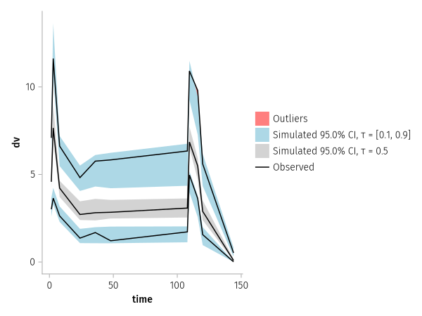

Figure 1: Visual Predictive Check

```julia
vpc_plot(vpc_result)
```

## 3.4 Log-Likelihood Profile

Log-likelihood profiling provides confidence intervals for individual parameters by fixing one parameter at a range of values and re-estimating the rest:

```julia
# Profile tvCL over a range around the estimate
# (computationally intensive — commented for rendering speed)
# cl_range = range(coef(base_fit).tvCL * 0.8, coef(base_fit).tvCL * 1.2, length = 20)
# profiles = [fit(pk_model, pop, merge(coef(base_fit), (tvCL = cl,)), FOCEI();
#             constantcoef = (tvCL = cl,)) for cl in cl_range]
# ll_values = loglikelihood.(profiles)
```

## 3.5 Diagnostics Summary

```
[ Info: Calculating predictions.
[ Info: Calculating weighted residuals.
[ Info: Calculating empirical bayes.
[ Info: Evaluating dose control parameters.
[ Info: Evaluating individual parameters.
[ Info: Done.
```

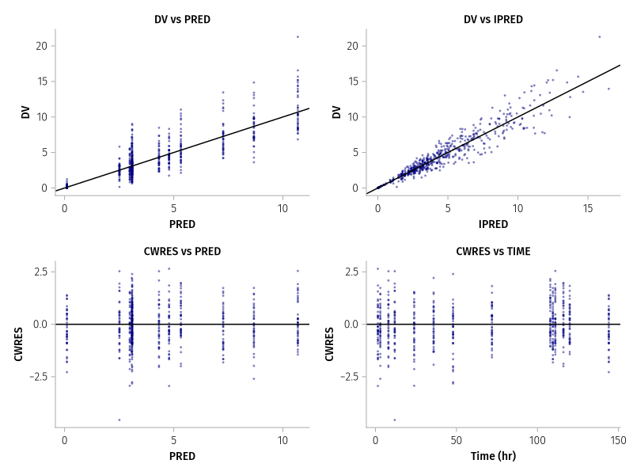

Figure 2: GOF Diagnostic Plots

```julia
insp = inspect(base_fit)
insp_df = DataFrame(insp)
obs = @rsubset(insp_df, !ismissing(:dv))

fig = Figure(size = (800, 600))

ax1 = Axis(fig[1, 1], xlabel = "PRED", ylabel = "DV", title = "DV vs PRED")
scatter!(ax1, obs.dv_pred, obs.dv, color = :navy, markersize = 4, alpha = 0.5)
ablines!(ax1, 0, 1, color = :black)

ax2 = Axis(fig[1, 2], xlabel = "IPRED", ylabel = "DV", title = "DV vs IPRED")
scatter!(ax2, obs.dv_ipred, obs.dv, color = :navy, markersize = 4, alpha = 0.5)
ablines!(ax2, 0, 1, color = :black)

ax3 = Axis(fig[2, 1], xlabel = "PRED", ylabel = "CWRES", title = "CWRES vs PRED")
scatter!(ax3, obs.dv_pred, obs.dv_wres, color = :navy, markersize = 4, alpha = 0.5)
hlines!(ax3, 0, color = :black)

ax4 = Axis(fig[2, 2], xlabel = "Time (hr)", ylabel = "CWRES", title = "CWRES vs TIME")
scatter!(ax4, obs.time, obs.dv_wres, color = :navy, markersize = 4, alpha = 0.5)
hlines!(ax4, 0, color = :black)

fig
```

# 4 Sensitivity Analysis

- Evaluate the impact of model assumptions and data exclusion on conclusions
- Re-estimate model with subsets of data removed (e.g., influential subjects)
- Compare results when assumptions are relaxed (e.g., different error models)

# 5 EDA-Driven Model Selection

Before evaluating a model’s adequacy, the right model structure must be selected. Exploratory data analysis provides the first line of evidence:

## 5.1 Hysteresis Detection

A concentration-effect (CE) plot reveals whether the response is in equilibrium with plasma concentrations:

| CE Plot Pattern | Interpretation | Model Implication |
| --- | --- | --- |
| No loop (single curve) | Equilibrium — effect tracks concentration | **Direct response** (Emax, sigmoid Emax) |
| Counter-clockwise loop | Effect lags behind concentration | **Effect compartment** (ke0 delay) |
| Clockwise loop | Tolerance, sensitization, or indirect mechanism | **Indirect response** (IDR Types I–IV) or tolerance model |

**Systematic Model Selection Framework**

1. **Exploratory Data Analysis** — Plot effect vs. time, concentration-effect loops, identify temporal patterns
2. **Mechanism-Based Selection** — Match drug pharmacology to model structure:
   - Receptor binding → Direct or effect compartment
   - Enzyme inhibition → IDR Type I or II
   - Signal transduction cascade → IDR with transit or effect compartment
   - Covalent binding → IDR Type IV or K-PD
3. **Statistical Comparison** — Among mechanistically plausible candidates, use AIC/BIC and GOF to select the best fit
4. **Qualification** — Bootstrap, VPC, sensitivity analysis for the selected model

## 5.2 Multi-Model Comparison

When comparing more than two candidate models:

```julia
# Compare multiple models systematically
fits = [fit1, fit2, fit3]
for (i, f) in enumerate(fits)
    println("Model $i — AIC: ", round(aic(f), digits=1),
            "  BIC: ", round(bic(f), digits=1),
            "  -2LL: ", round(-2*loglikelihood(f), digits=1))
end

# Or use metrics_table for side-by-side comparison
metrics_table(fit1, fit2, fit3)

# LRT for nested pairs only
lrtest(fit1, fit2)  # only valid when fit1 is nested within fit2
```

# 6 Study Guide Questions

1. What are the key differences between model evaluation and model qualification?
2. When would you use a bootstrap analysis instead of asymptotic standard errors?
3. What does a VPC tell you that GOF plots do not?
4. When is model qualification less important?
5. What are the limitations of the likelihood ratio test for model comparison?

# 7 Supplementary Material

| Topic | Tutorial | Key Additions |
| --- | --- | --- |
| **Lecture: Graphical Diagnostics** | PKPD W6 | DV vs PRED/IPRED interpretation, CWRES patterns, time-dependent misspecification |
| **Lecture: Residual Diagnostics & Error Models** | PKPD W7 | Additive vs proportional vs combined error, residual analysis methodology |
| **Lecture: Base Model & Likelihood Comparison** | PKPD W5 | -2LL, LRT, AIC/BIC theory, model comparison workflow |
| PD model selection framework | [PD Model Selection](https://tutorials.pumas.ai/html/PDModels/05-model-selection.html) | EDA → mechanism → statistics workflow, hysteresis detection, warfarin case study |
| Bayesian model comparison | [Bayesian Model Comparison](https://tutorials.pumas.ai/html/bayesian/05-model_comparison.html) | WAIC, LOO-CV, Bayes factors for non-nested models |
| VPC customization | [Continuous VPC](https://tutorials.pumas.ai/html/LearningPaths/04-LP/11-Module/ContinuousVPC.html) | Stratified VPC, prediction-corrected VPC, log-scale |